# Meeting 10 - Correlation and Linear Regression

Matthew E. Aiello-Lammens

2020-04-15

# Today’s Goals

- Introduce foundations of statistical models
- Become familiar with key concepts of linear modeling
- Introduce concepts of covariation and correlation
- Identify relationship between correlation and linear regression

# Introduction to Linear Models

## Statistical Models

From Logan, p. 151:

> A **statistical model** is an expression that attempts to explain patterns in the observed values of a *response variable* by relating the response variable to a set of *predictor variables* and parameters.

A generic model looks like:

response variable = model + error

### Simple linear model

$$y = bx + a$$

where $b$ is the slope and $a$ is the y-intercept.

**Written Notes - pages 1-3**

## Co-variation

Calcualte covariation between sepal length and sepal width, using the `iris` dataset.

```r
data(iris)
head(iris)
```

```
##   Sepal.Length Sepal.Width Petal.Length Petal.Width Species
## 1          5.1         3.5          1.4         0.2  setosa
## 2          4.9         3.0          1.4         0.2  setosa
## 3          4.7         3.2          1.3         0.2  setosa
## 4          4.6         3.1          1.5         0.2  setosa
## 5          5.0         3.6          1.4         0.2  setosa
## 6          5.4         3.9          1.7         0.4  setosa
```

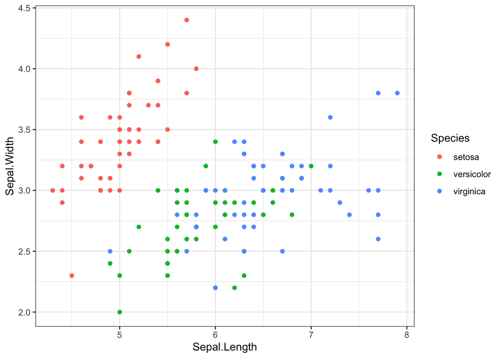

```r
library(ggplot2)
ggplot(data = iris) +
  geom_point(aes(x = Sepal.Length, y = Sepal.Width, colour = Species)) +
  theme_bw()
```

```r
covar <- sum((iris$Sepal.Length - mean(iris$Sepal.Length)) * (iris$Sepal.Width - mean(iris$Sepal.Width)))/ (nrow(iris) - 1)

## Confirm
var(x = iris$Sepal.Length, y = iris$Sepal.Width)
```

```
## [1] -0.042434
```

**Written Notes - Page 4**

## Correlation

Calculate the correlation between sepal length and sepal width, and calculate whether $r$ is significantly different from 0 or not.

```r
cor_iris <- covar / (sd(iris$Sepal.Length)*sd(iris$Sepal.Width))

se_cor_iris <- sqrt((1 - cor_iris^2)/(nrow(iris) - 2))

t_cor_iris <- cor_iris/se_cor_iris

## Calculate the probability of getting our t value, or one more extreme
pt(q = t_cor_iris, df = (nrow(iris)-2))*2
```

```
## [1] 0.1518983
```

```r
## Use `cor` to find correlation value
with(data = iris, cor(x = Sepal.Length, y = Sepal.Width, method = "pearson"))
```

```
## [1] -0.1175698
```

```r
## Test the correlation
with(data = iris, cor.test(x = Sepal.Length, y = Sepal.Width, method = "pearson"))
```

```
##
##  Pearson's product-moment correlation
##
## data:  Sepal.Length and Sepal.Width
## t = -1.4403, df = 148, p-value = 0.1519
## alternative hypothesis: true correlation is not equal to 0
## 95 percent confidence interval:
##  -0.27269325  0.04351158
## sample estimates:
##        cor
## -0.1175698
```

## Robust correlation

For Pearson’s correlation coefficient to be appropriate, the data should have:

1. A linear relationship
2. A bivariate normal distribution
- Spearman’s Rank Correlation - calculates correlation on ranks of observed values
- Kendall’s Rank Correlation

# Linear regression

Now we assume that any change in **y** is due to a change in **x**.

## Example of linear regression

Effects of starvation and humidity on water loss in the confused flour beetle. Here, looking at the relationship between humidity and weight loss

```r
flr_beetle <- read.csv(file = "https://mlammens.github.io/ENS-623-Research-Stats/data/Logan_Examples/Chapter8/Data/nelson.csv")
flr_beetle
```

```
##   HUMIDITY WEIGHTLOSS
## 1      0.0       8.98
## 2     12.0       8.14
## 3     29.5       6.67
## 4     43.0       6.08
## 5     53.0       5.90
## 6     62.5       5.83
## 7     75.5       4.68
## 8     85.0       4.20
## 9     93.0       3.72
```

Plot these data

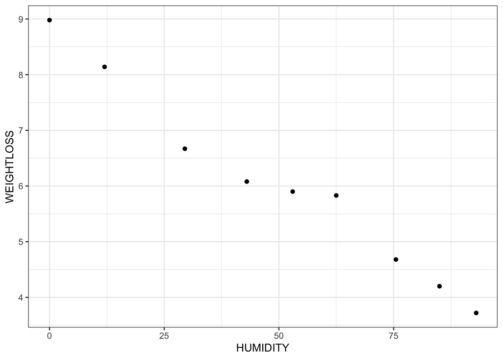

```r
library(ggplot2)
ggplot() +
  geom_point(data = flr_beetle, aes( x = HUMIDITY, y = WEIGHTLOSS)) +
  theme_bw()
```

Run a linear regression

```r
flr_beetle_lm <- lm(data = flr_beetle, WEIGHTLOSS ~ HUMIDITY)
summary(flr_beetle_lm)
```

```
##
## Call:
## lm(formula = WEIGHTLOSS ~ HUMIDITY, data = flr_beetle)
##
## Residuals:
##      Min       1Q   Median       3Q      Max
## -0.46397 -0.03437  0.01675  0.07464  0.45236
##
## Coefficients:
##              Estimate Std. Error t value Pr(>|t|)
## (Intercept)  8.704027   0.191565   45.44 6.54e-10 ***
## HUMIDITY    -0.053222   0.003256  -16.35 7.82e-07 ***
## ---
## Signif. codes:  0 '***' 0.001 '**' 0.01 '*' 0.05 '.' 0.1 ' ' 1
##
## Residual standard error: 0.2967 on 7 degrees of freedom
## Multiple R-squared:  0.9745, Adjusted R-squared:  0.9708
## F-statistic: 267.2 on 1 and 7 DF,  p-value: 7.816e-07
```

Plot these data, with `lm` fit

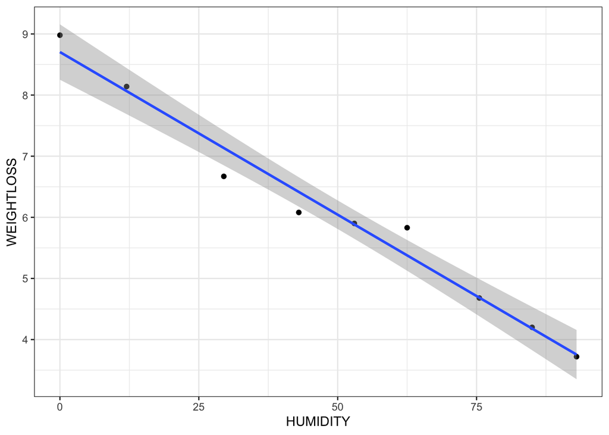

```r
ggplot(data = flr_beetle, aes( x = HUMIDITY, y = WEIGHTLOSS)) +
  geom_point() +
  stat_smooth(method = "lm") +
  theme_bw()
```

### Linear regression assumptions

#### The big three:

1. **Normality:** The $y_i$ **AND** error values ($\epsilon_i$) are normally distributed. If normality is violated, *p*-values and confidence intervals may be inaccurate and unreliable.
2. **Homogeneity of variance:** The $y_i$ **AND** error values ($\epsilon_i$) have the same variance for each $x_i$.
3. **Independence:** The $y_i$ **AND** error values are independent of *each other*.

#### Other assumptions:

- **Linearity:** The relationship between $x_i$ and $y_i$ is linear (only important when using simple linear regression).
- **Fixed X values:** The $x_i$ values are measured without error. In practice this means the error in the $x_i$ values is much smaller than that in the $y_i$ values.

### Linear regression diagnostics

- **Leverage:** a measure of how extreme a value in **x-space** is (i.e., along the x-axis) and how much of an influence each $x_i$ has on $\hat{y}_i$. High leverage values indicate that model is unduly influenced by an outlying value.
- **Residuals:** the differences between the observed $y_i$ values and the predicted $\hat{y}_i$ values. Looking at the pattern between residuals and $\hat{y}_i$ values can yield important information regarding violation of model assumptions (e.g., homogeneity of variance).
- **Cook’s D:** a statistics that offers a measure of the influence of each data point on the fitted model that incorporates both leverage and residuals. Values $\ge 1$ are considered “suspect”.

If we plot the `lm` result, we will see a set of diagnostic plots:

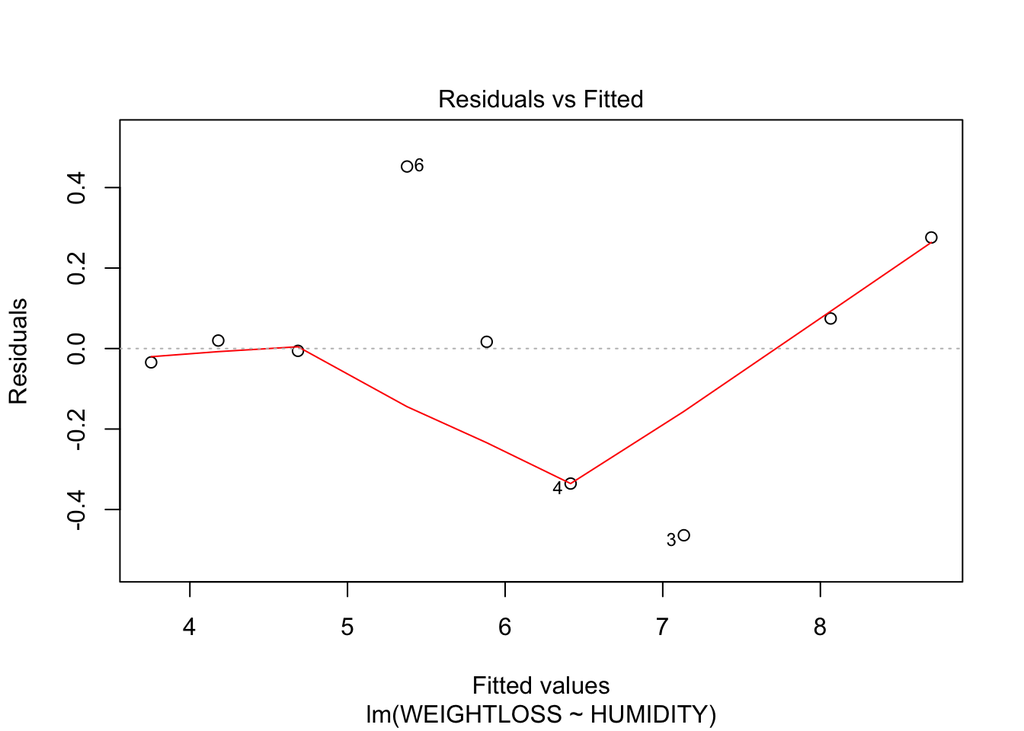

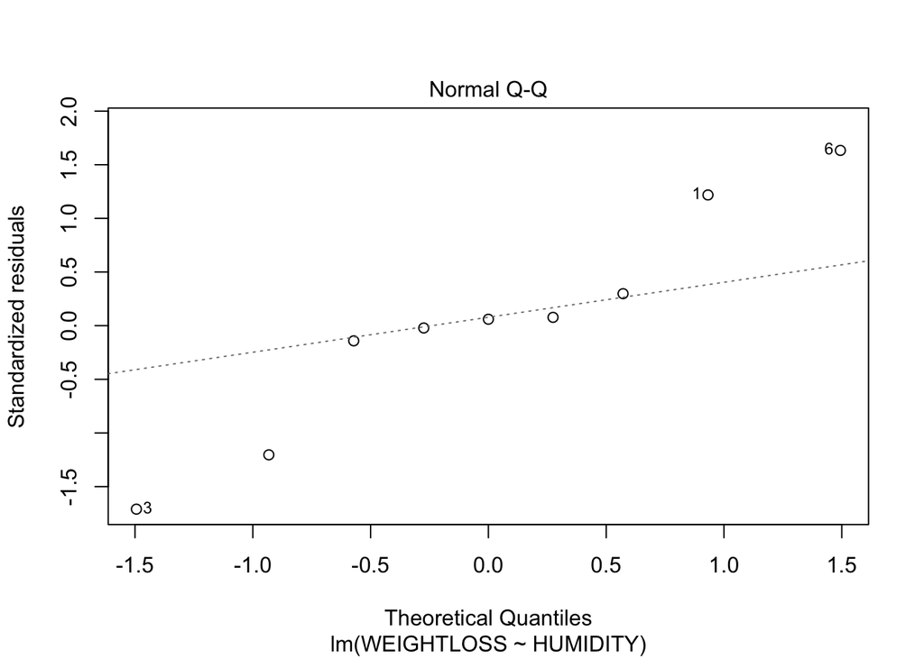

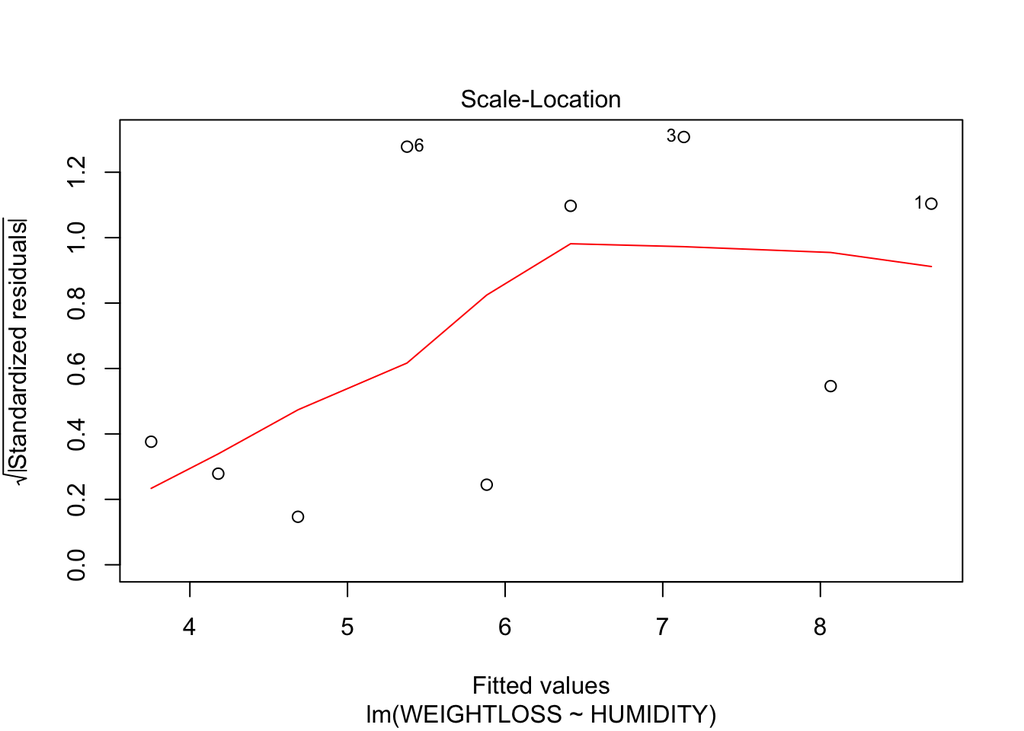

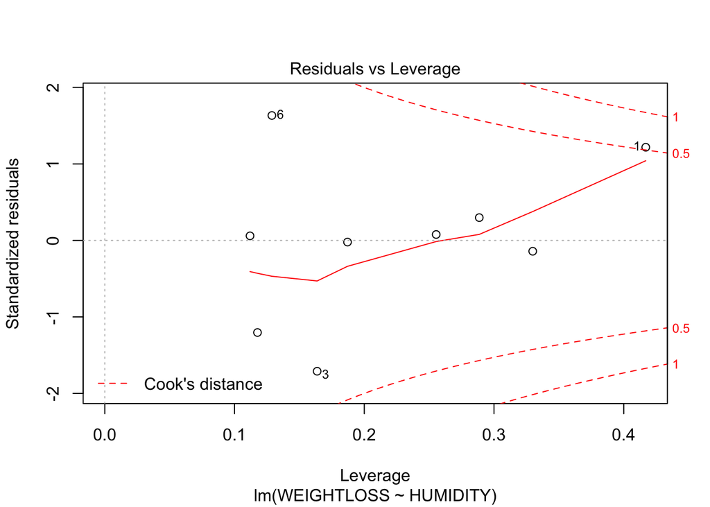

```r
plot(flr_beetle_lm)
```

## Standard error of regression coefficients, the regression line, and $\hat{y}_i$ predictions

Regression coefficients are statistics and thus we can determine the standard error of these statistics. From there, we can use these values and the *t*-distribution to determine confidence intervals. For example, the confidence interval for $b_1$ is:

$$b_1 \pm t_{0.05, n-2}s_{b_{1}}$$

### $\beta_1$ standard error

$$s_{b_{1}} = \sqrt{ \frac{MS_{Residual}}{\sum^n_{i=1}(x_i-\bar{x})^2} }$$

### $\beta_0$ standard error

$$s_{b_{0}} = \sqrt{ MS_{Residual} [\frac{1}{n} + \frac{\bar{x}^2}{\sum^n_{i=1}(x_i-\bar{x})^2}] }$$

### Confidence bands for regression line

From Quinn and Keough, p. 87:

> The 95% confidence band is a biconcave band that will contain the true population regression line 95% of the time.

### $\hat{y}_i$ standard error

$$s_{\hat{y}} = \sqrt{ MS_{Residual} [1 + \frac{1}{n} + \frac{x_p - \bar{x}^2}{\sum^n_{i=1}(x_i-\bar{x})^2}] }$$

where $x_p$ is the value from $x$ we are “predicting” a $y$ value for.

## My model looks good, but is it meaningful?

In order to determine if your linear regression model is meaningful (or *significant*) you must compare the **variance explained** by your model versus the **variance unexplained**.

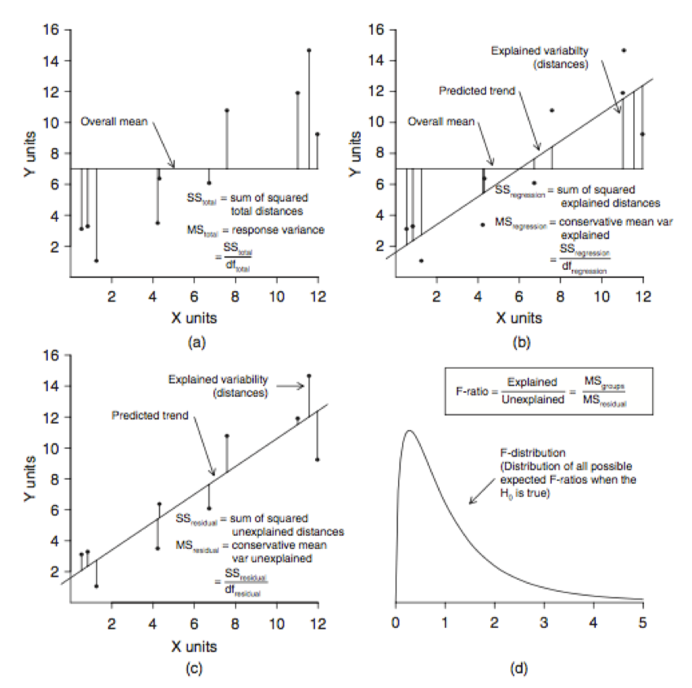

Logan - Figure 8.3

Note that there is a typo in this figure in panel (c). Instead of “Explained variability”, the arrow tag should be “Unexplained variability”.

# Regression and regression-like techniques we will not be covering in depth

Below is a list of techniques that are covered well in both of the class textbooks.

- Model II regression - e.g. Major axis regression. Used to deal with uncertain $x_i$ values
- Running medians - generation of predicted values ($\hat{y}_i$) that are *medians* of the responses in the bands surrounding each observation
- LOESS (or LOWESS) - local least-square regression fits, glued together
- kernel smoothers - weighted average values of $y_i$’s within a band of $x_i$ values
- splines - combined series of polynomial fits generated using windows of the data